# Background of Rubella Vaccination in Japan

Preview

Hiroki Kato

2022-04-22

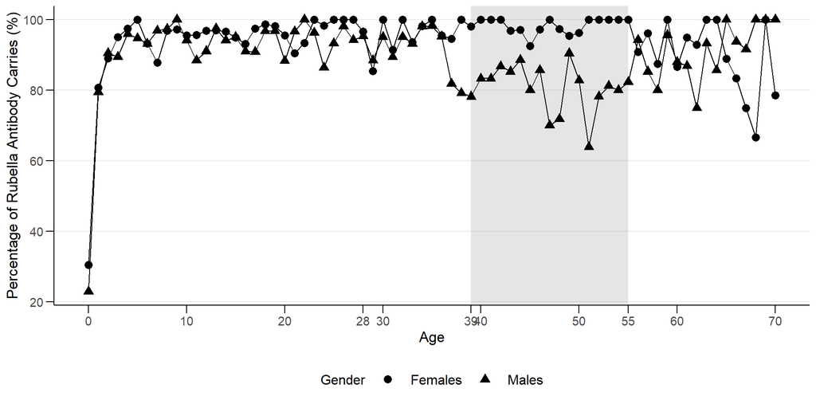

Figure 1: Percentage of Rubella Antibody Carriers at Each Age by Gender. Data: NIID “2018 National Epidemiological Surveillance of Vaccine-Preventable Diseases (NESVPD).”

図1は国立感染症研究所（NIID）の 2018年度感染症流行予測調査の男女別・年齢別の風しん抗体保有率をプロットしたものである。 39-55歳の男性の抗体保有率は約80.7%であり、 同じ世代の女性（約98.3%）や他の世代と比較して低いことが分かる[^1]。 これは39-55歳の男性が定期接種として風しんワクチンを接種していないこと、 さらに、風しんに自然感染していないことを反映している[^2]。 56歳以上の男性と女性の抗体保有率はそれぞれ91.3%と89.4%である。 彼らは風しんワクチンの定期接種を受けていないが、 風しんが流行していた期間に育っているので、 感染を通じて抗体を保有している。 38歳以下の男性と女性の抗体保有率はそれぞれ91.3%と94.0%である。 彼らは定期接種を通じて少なくとも1回の風しんワクチンを接種している。

Kinoshita and Nishiura (2016) によれば、 すべての世代で抗体保有率が90%を超えれば、 日本で風しんの集団免疫が獲得できる[^3]。 これを達成するために、厚生労働省は2019年4月から2022年3月までの間で、 風しん定期接種の追加対策を実施することを決めた。 対象者は2019年時点で40-57歳の男性である[^4]。 ワクチン接種の効率的な活用のために、対象の男性は、はじめに抗体検査を受検する。 抗体検査により抗体が持っていないことが明らかになった男性は風しんワクチンを接種する。 この追加的対策の政策目標は、2022年3月までに、 対象世代の男性の抗体保有率を80%から90%に引き上げることである。

この追加対策は予防接種法に基づく定期接種であり、 対象となる男性は対象期間において無料で抗体検査とワクチン接種を受けられる。 追加対策を円滑に進める観点から、 地方自治体が風しんの抗体検査とワクチン接種の無料クーポン券を3年かけて段階的に対象世代の男性に送付した。 2019年度にクーポン券が自動的に送付されるかどうかという観点で、 追加対策の対象男性は以下の二つのグループに分けられる。

1. 40-46歳の男性：クーポン券が自動的に送付される
2. 47-57歳の男性：2020年度以降にクーポン券が自動的に送付されるが、 市区町村の判断もしくは本人の希望によって、2019年度にクーポン券を受け取れる

Kinoshita, Ryo, and Hiroshi Nishiura. 2016. “Assessing Herd Immunity Against Rubella in Japan: A Retrospective Seroepidemiological Analysis of Age-Dependent Transmission Dynamics.” *BMJ Open* 6 (1): e009928. https://doi.org/10.1136/bmjopen-2015-009928.

Nishiura, Hiroshi, Ryo Kinoshita, Yuichiro Miyamatsu, and Kenji Mizumoto. 2015. “Investigating the Immunizing Effect of the Rubella Epidemic in Japan, 2012-14.” *International Journal of Infectious Diseases* 38 (September): 16–18. https://doi.org/10.1016/j.ijid.2015.07.006.

Plans-Rubió, Pedro. 2012. “Evaluation of the Establishment of Herd Immunity in the Population by Means of Serological Surveys and Vaccination Coverage.” *Human Vaccines & Immunotherapeutics* 8 (2): 184–88. https://doi.org/10.4161/hv.18444.